# Hidden Markov CAPMs: Industry Portfolios

## Data

Data is imported from [Kenneth French's data library](http://mba.tuck.dartmouth.edu/pages/faculty/ken.french/data_library.html) and [FRED](https://fred.stlouisfed.org/series/). Currently, this workbook uses 49 industry portfolios and the FF3 factors. Additionally, NBER recession indicators complement the data.

## Model

### Theory

The rationale for the model goes as follows:

Let $r^i_{t}$ and $r^M_{t}$ denote excess returns on an asset $i$ and the market portfolio.

Investors use a standard CAPM to form expectations about means and variances of asset excess returns: $$\mathbb{E}_t\big[r^i_{t+1}\big] = \alpha^i + \beta^i \, \mathbb{E}_t\big[r^{M}_{t+1}\big]$$ $$\mathbb{V}_t\big[r^i_{t+1}\big] = (\sigma^i)^2$$

Now suppose agents are ambiguous about the set of model-parameters that are generating next-period returns. In particular, there are two competing sets of parameters $\theta^i_{S_{t+1}} = \big(\alpha^i_{S_{t+1}}, \beta^i_{S_{t+1}}, \sigma^i_{S_{t+1}}\big)$, where $S_{t+1} \in \{0,1\}$, and the transition between the two sets of parameters follows a Markov process:

\begin{equation*} \begin{cases} r^i_{t+1} = \alpha^i_{S_{t+1}=0} + \beta^i_{S_{t+1}=0} \, \mathbb{E}_t\big[r^M_{t+1}\big] + \varepsilon^i_{t+1}, \quad\quad \varepsilon^i_{t+1} \sim \mathcal{N}\big(0,(\sigma^i_{S_{t+1}=0})^2\big)\\ r^i_{t+1} = \alpha^i_{S_{t+1}=1} + \beta^i_{S_{t+1}=1} \, \mathbb{E}_t\big[r^M_{t+1}\big] + \varepsilon^i_{t+1}, \quad\quad \varepsilon^i_{t+1} \sim \mathcal{N}\big(0,(\sigma^i_{S_{t+1}=1})^2\big) \end{cases} \end{equation*}\begin{equation*} P\big(S^i_{t+1} = s^i_{t+1} \, \big| \, S^i_{t} = s^i_{t}\big) = \begin{bmatrix} p^i_{00} & 1-p^i_{00}\\ p^i_{10} & 1-p^i_{10}\\ \end{bmatrix} \end{equation*}

Given the two-regime markov process, investors are ambiguous between two Gaussian distributions that next-period returns could be drawn from: \begin{equation} \begin{cases} \phi_0(r^i_{t+1}) = \mathcal{N}\big(\mu^i_0 = \alpha^i_{0} + \beta^i_{0} \, \mathbb{E}_t\big[r^M_{t+1}\big],(\sigma^i_{0})^2\big), \quad \text{with probability } P_t(S^i_{t+1} = 0)\\ \phi_1(r^i_{t+1}) = \mathcal{N}\big(\mu^i_1 = \alpha^i_{1} + \beta^i_{1} \, \mathbb{E}_t\big[r^M_{t+1}\big],(\sigma^i_{1})^2\big), \quad \text{with probability } P_t(S^i_{t+1} = 1) = \big[1-P_t(S^i_{t+1} = 0)\big] \end{cases} \end{equation} For both distributions, $\beta^i_{S_{t+1}}$ reflects the state-dependent level of systematic risk, while $(\sigma^i_{S_{t+1}})^2$ denotes the asset's state-dependent level of idiosyncratic risk.

With knowledge of regime-probabilities at time $t$, next-period $t+1$ regime-probabilities are given by: \begin{equation*} \begin{bmatrix} P_t(S^i_{t+1} = 0)& P_t(S^i_{t+1} = 1)\\ \end{bmatrix}= \begin{bmatrix} P_t(S^i_{t} = 0)& P_t(S^i_{t} = 1)\\ \end{bmatrix} \begin{bmatrix} p^i_{00} & 1-p^i_{00}\\ p^i_{10} & 1-p^i_{10}\\ \end{bmatrix} \end{equation*}

Note that although both priors rely on normality assumptions, the weighted expectiation about the next-period return distribution (by probability-weighting the two priors) is no longer normal. Instead, it follows a mixture distribution $\mathcal{D}\big(\mu^i_D,(\sigma^i_D)^2,.\big)$ with first and second moments $\mu^i_D$ and $(\sigma^i_D)^2$, and finite higher moments: \begin{align} \mathbb{E}_t\big[\phi(r^i_{t+1})\big] &= P_t(S^i_{t+1} = 0) \times \phi_0(r^i_{t+1}) + \big[1-P_t(S^i_{t+1} = 0)\big] \times \phi_1(r^i_{t+1})\\ &= P_t(S^i_{t+1} = 0) \times \mathcal{N}\big(\mu^i_0,(\sigma^i_{0})^2\big) + \big[1-P(S^i_{t+1} = 0)\big] \times \mathcal{N}\big(\mu^i_1,(\sigma^i_{1})^2\big)\\ %&= N\big(P(S^i_{t+1} = 0) \times \big(\alpha^i_{0} + \beta^i_{0} \times \mathbb{E}_t\big[r^M_{t+1}\big]\big) + \big[1-P_t(S^i_{t+1} = 0)\big] \times \big(\alpha^i_{1} + \beta^i_{1} \times \mathbb{E}_t\big[r^M_{t+1}\big]\big), \quad P(S^i_{t+1} = 0) \times (\sigma^i_{0})^2 + \big[1-P_t(S^i_{t+1} = 0)\big] \times (\sigma^i_{0})^2 \big) %&= \mathcal{D}\big(P(S^i_{t+1} = 0) \times \big(\alpha^i_{0} + \beta^i_{0} \times \mathbb{E}_t\big[r^M_{t+1}\big]\big)+ \big[1-P(S^i_{t+1} = 0)\big] \times \big(\alpha^i_{1} + \beta^i_{1} \times \mathbb{E}_t\big[r^M_{t+1}\big]\big)\big)\\ %&= \mathcal{D}\big(\alpha^i_{w} + \beta^i_{w} \times \mathbb{E}_t\big[r^M_{t+1}\big]\big) &= \mathcal{D}\big(\mu^i_D,(\sigma^i_D)^2,.\big) \end{align}

The first two moments of $\mathcal{D}(.)$ are given by: \begin{align*} \mu^i_D &= \sum_{s_{t+1}=0}^{1} P_t(S^i_{t+1} = s_{t+1}) \times \mu^i_{s_{t+1}} &= \mathbb{E}_t\big[r^i_{t+1}\big] \\ (\sigma^i_D)^2 &= \sum_{s_{t+1}=0}^{1} P_t(S^i_{t+1} = s_{t+1}) \times (\sigma^i_{s_{t+1}})^2 + \sum_{s_{t+1}=0}^{1} P_t(S^i_{t+1} = s_{t+1}) \times (\mu^i_{s_{t+1}})^2 - \Big(\sum_{s_{t+1}=0}^{1} P_t(S^i_{t+1} = s_{t+1}) \times \mu^i_{s_{t+1}}\Big)^2 &= \mathbb{V}_t\big[r^i_{t+1}\big] \end{align*}

Note that these moments can be interpreted as the expected return and expected total variance of asset $i$'s return.

### Estimation

Empirically, we can estimate a Markov regime switching model in historical return data for each asset $i$. Intercept $\alpha^i_{S_t}$, market beta $\beta^i_{S_t}$ and error variance $(\sigma^i_{S_t})^2$ are state-dependent, while transition probabilities $p_{00}$ and $p_{10}$ are static. More formally:

\begin{equation*} r^i_t = \alpha^i_{S_t} + \beta^i_{S_t} \, r_t^M + \varepsilon^i_{t}, \quad\quad \varepsilon^i_{t} \sim \mathcal{N}\big(0,(\sigma^i_{S_t})^2\big), \quad\quad S_t \in \{0,1\} \end{equation*}\begin{equation*} P_{t-1}\big(S^i_{t} = s^i_{t} \, \big| \, S^i_{t-1} = s^i_{t-1}\big) = \begin{bmatrix} p^i_{00} & 1-p^i_{00}\\ p^i_{10} & 1-p^i_{10}\\ \end{bmatrix} \end{equation*}

The parameters $p^i_{00}, p^i_{10}, \alpha^i_0, \alpha^i_1, \beta^i_0, \beta^i_1, (\sigma^i_{1})^2, (\sigma^i_{2})^2$ and their standard errors are estimated by maximum likelihood. Restrictions of the general model such as $\alpha^i_0 = \alpha^i_1$ or $(\sigma^i_{0})^2 = (\sigma^i_{1})^2$ are possible, but the current version does not restrict the general model.

From the estimation, we also obtain filtered probabilities and smoothing probabilites to be in either regime for all in-sample periods.

In addition, a standard linear regression model for each asset and data window is also estimated: $$r^i_t = \alpha^i+\beta^i \, r^M_t, \quad\quad \varepsilon^i_t \sim \mathcal{N}\big(0,(\sigma^i)^2\big)$$ This can serve as a benchmark and help distinguish periods in which there really were multiple possible regimes at work.

## Full sample models

To first analyse if this approach yields any meaningful results, we fist estimate the HMM CAPM specification in the full sample starting from January 1960.

### Summary

The estimation of the 49 industry models is sumarised below. Fields that are true, are marked in green, whereas false is marked in red.

Panel 1 contains some general descriptive statistics regarding the estimated HMM models. First, we observe that all models have converged to a solution given the numerical solver. Starting values in the maximum likelihood estimations are the OLS estimates. To exclude unwanted local maxima and assure the estimated solutions make sense two additional undesirable properties of the estimated Markov chains are reported:

- **Non-ergodicity/Reducability**: Either $p_{00} = 1$ or $p_{11} = 1$. This implies the existance of an absorbing state that, once reached, will be the state of nature forever onwards.
- **Periodicity**: Either $p_{00} = 0$ or $p_{11} = 0$. This implies the existance of a state that will never last for longer than one period. Whenever reached, the Markov process immediately jumps back to the other state with complete certainty. Besides the resulting perfect state-predictability, this is undesirable in an empirical exercise since it means that the estimation procedure converged to values that capture single outliers in a separate state.

Panel 2 compares the model fit of the HMM models to the corresponding values of simple CAPM models estimated by OLS. The OLS likelihood provides a lower bound for the HMM models as it can just stay at the OLS estimates if that is optimal. Given the amount of estimated parameters (eight instead of two), model selection criteria that take into account their number are better suited for comparison. In the full sample, HMM estimates still seem to add descriptive power to the standard CAPM in most industries.

Panel 3 reports the significance of the estimated parameters in OLS. The confidence level is 95%. This is reported to serve as a benchmark for the more complex models.

Panel 4 repeats the same for the HMM models. As can be seen, most alpha estimates are insignificant just as in the OLS specification. Most other estimated parameters are significant at 95%.

Panel 5 repeats the significance tests for the HMM parameters against the null of the OLS estimates being true. Now most the differences arise from the idiosyncratic volatility estimates, whereas betas are frequently not distinguishable from the OLS estimates in the statistical sense.

Panel 6 reports significance tests for the estimated parameter spreads of the two regimes. The difference for each parameter pair is tested using a two-sample t-statistic, e.g. for $H_0: \beta^i_0=\beta^i_1$: $$t_{[\beta^i_0=\beta^i_1]} = \frac{\beta^i_0-\beta^i_1}{\sqrt{\big[s.e.(\beta^i_0)\big]^2+\big[s.e.(\beta^i_1)\big]^2 - 2 \, cov(\beta^i_0,\beta^i_1)}}$$ Again, the HMM models mostly attain significant spreads in the idiosyncratic volatilities.

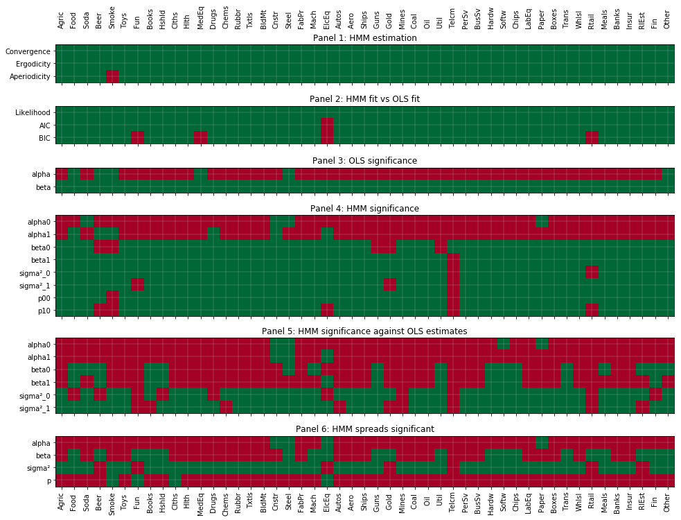

### Estimated parameters

#### Regime switches

To describe cross-sectional differences in the characteristics of the regime-Markov-chains, we calculate expected regime durations for each estimated model as the average of both regimes' expected durations: $$\text{Expected regime duration} = \frac{\frac{1}{1-p_{00}}+\frac{1}{1-p_{11}}}{2}$$ The chart below shows time-series averages by industry in ascending order. While most industries are estimated in an economically reasonable range, a few industries stand out with extremely short or long expected regime durations. On the lower end are mostly the industries that have been documented to be problematic in terms of fit in the previous part. The upper end is not is not necessarily problematic in the full sample, but given the estimated low switching probabilities these models likely pose a challange for estimation in shorter sample periods.

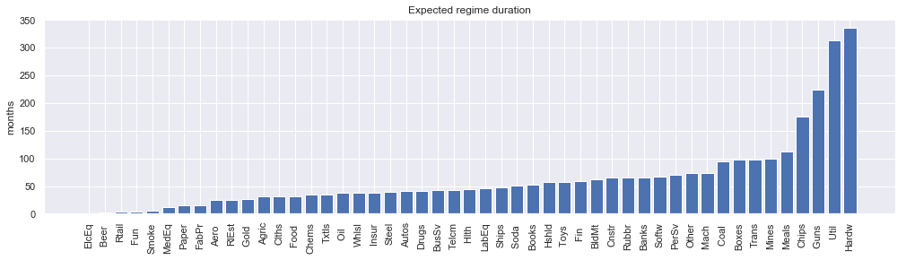

#### Parameter spreads

Next, the HMM parameter estimates are compared with their OLS counterparts. Note that the Markov probabilities have no OLS equivalents and are therefore not reported here. Industries are ordered based on their beta spreads under the HMM models. The dashed black line signifies the OLS benchmark.

As can be observed from the charts, most OLS estimates are contained in the interval of HMM estimates. All estimates seem to fall in an economically reasonable range and no relation of the various spreads is obvious. Industries with relatively large spreads in one dimension do not necessarily come with large spreads in other dimensions. This hints towards different areas of regime changes being relevant for various industries.

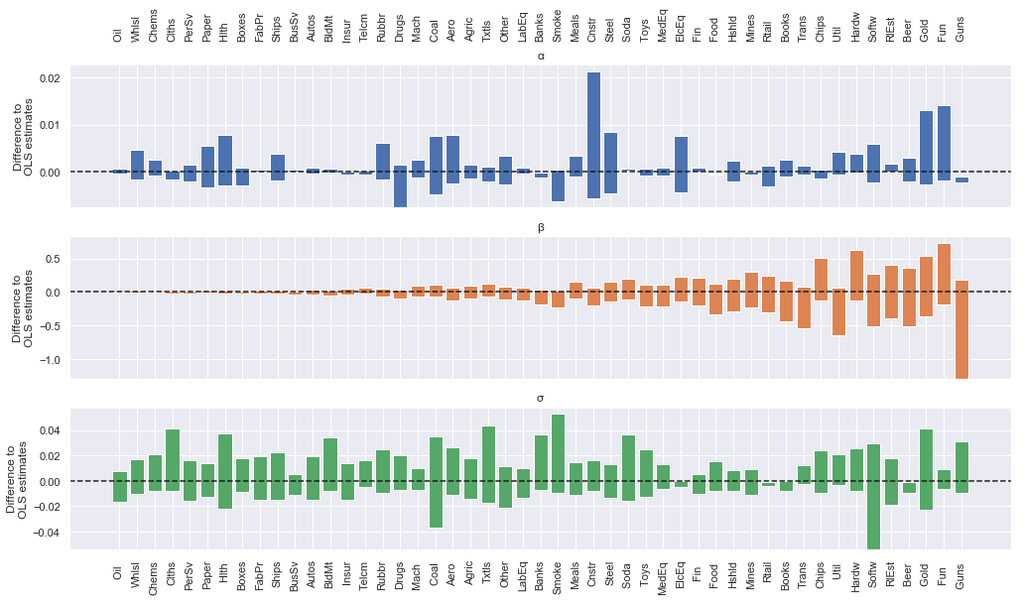

### The different dimensions of regime changes

Now let us have a closer look at some HMM models to better understand what insights these models offer into the data. From the previous part we saw that the estimated regimes can differ along three dimensions: alpha, beta, and idiosyncratic risk. What follows are three selected cases where the regime changes are described in primarily one of these dimensions. Additionally, a model with questionable solution is displayed.

For each case there are three charts.

1. A scatter plot that shows how a standard CAPM model (OLS) fits the data. Observations that lay further in the past are fading in size and saturation to illustrate the time dimension.
2. A scatter plot that illustrates the 2-regime CAPM model (HMM). The existance of two regimes means that there are also two regression lines fit to the data that are illustrated as a red and a blue line. More recent observations are again plotted in larger size. In contrast to the Standard CAPM graph, observations are now color-coded according to their smoothed regime probabilities, where red points belong to regime 0 with high probability, and blue points are attributed to regime 1. Shades in between are not clearly matched.
3. A time series plot of the regime probabilities over time. One added insight of the HMM models over OLS is that the time dimension of the data is not ignored, but instead the order of occurence is accounted for in the estimation. Therefore, we obtain regime probabilities for each observation. Given the underlying markov process, regimes are clustered over time, whcih can also be observed in the HMM scatter plot. Additionally to the smoothed probabilities (with knowledge of the whole sample), filtered probabilities (only accounts for past observations) are depicted as a dashed black line.

##### Case 1: Volatility switching (Oil Industry)

The first case contains models where the regime swithing behaviour is almost exclusively decribed by two idiosyncratic volatility regimes (alpha and beta spreads are insignificant). One such example is the oil industry. Regression lines almost coincide with the OLS estimates, exept that some periods entail higher error variance.

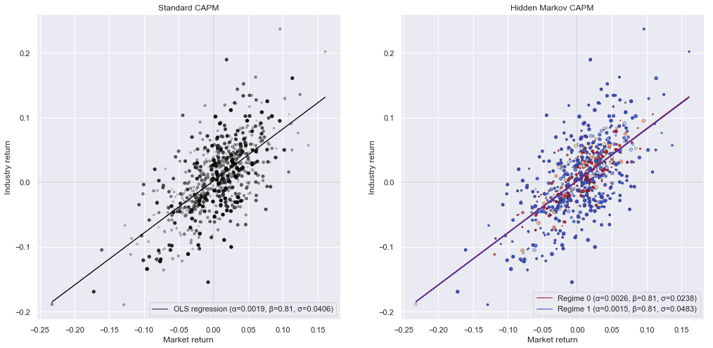

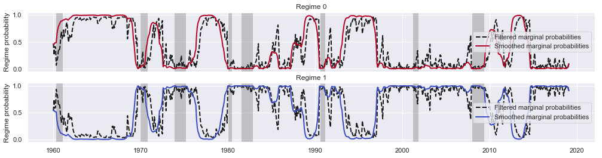

##### Case 2: Alpha switching (Construction Industry)

A second case comes with a large difference in estimated alphas. In its purest form this would mean a parallel shift of the CAPM regression line. However, no industry displays such behaviour alone and alpha spreads are mostly significant for models that are problematic in other regards. Below displayed is the model for the construction industry. Although there is a visible shift in the fitted intercepts, the regimes appear to be differentiated by more than just alpha. In particular, the difference in idiosyncratic volatility seems to drive the regimes.

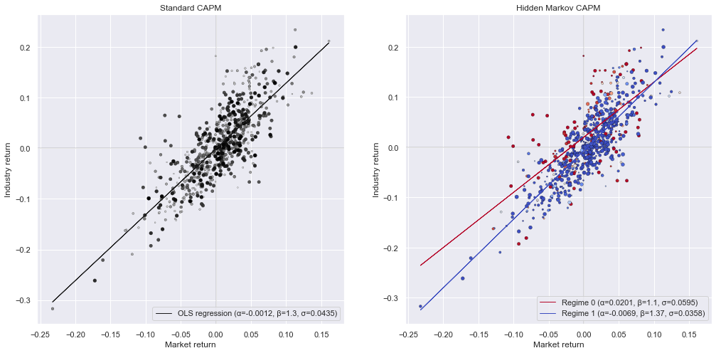

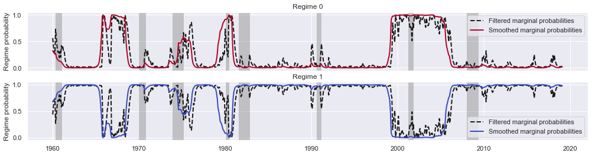

##### Case 3: Beta switching (Guns Industry)

In this case, the betas under the two regimes differ significantly. The guns industry offers such an example. Although idiosyncratic volatility again appears to be necessary as a free parameter, the most obvious visual difference comes from the changeing sign of the regression slope. Turning to the smoothed marginal probabilities over time, there seems to be a clearly distinct period around 2000 where the CAPM regime changed. Note that the negative sloping beta under regime 1 is not significantly identified.

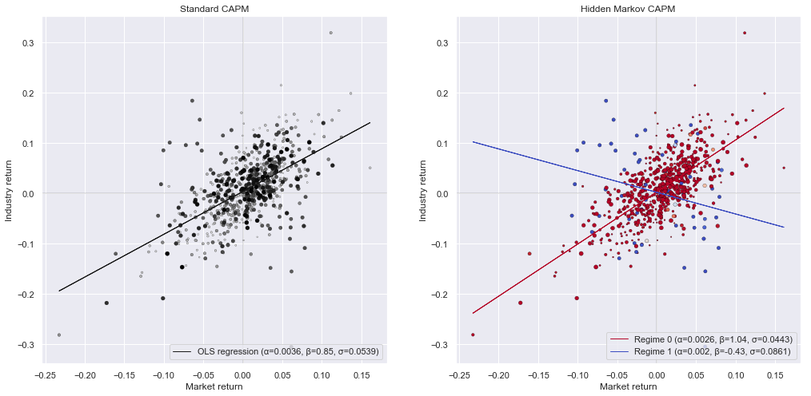

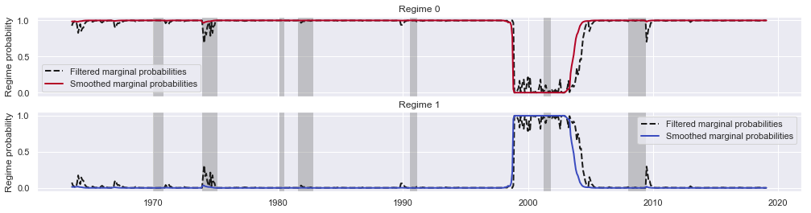

##### Case 4: Poor identification (Beer industry)

Last, let us see an example where the HMM is likely misspecified. The crucial point seems to be to identify the parameters of the Markov chain. With values of 0.69 and 0.54, regime switches occur more often than every other period. Only the former value is significant at 95% (against the null of being equal to zero, which may not be the right hypothesis to test against for the switching probabilities). As a result, for most observations the model does not identify a regime that likely generated the data point.

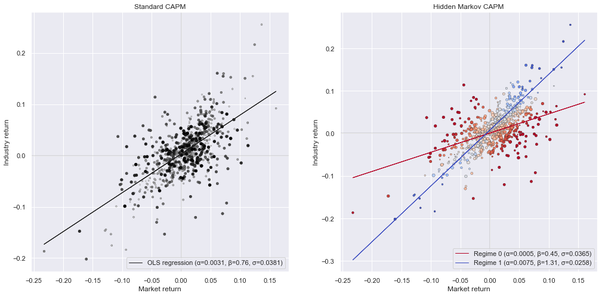

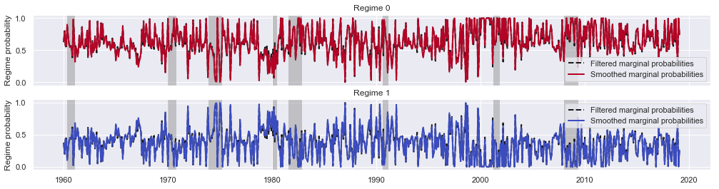

To conclude, it seems that most regime changes actually stem from changes in idiosyncratic volatility, and not market beta or alpha. In addition, close attention should be paid to the values the parameters converge to and their significance.

## Expanding window models

Next, to investigate if HMM CAPM models add any predictive power to regular CAPM models, we use expanding windows estimation to incorporate only backward looking data. The first window uses 60 months of monthly data (with at least 48 months being available) to obtain estimates and the procedure is repeated while adding one additional observation at a time. Although the standard CAPM is often estimated in rolling windows with a shorter period, HMM estimates are more meaningful if more data is considered. That way regime shifts that only infrequently occur can be captured.

### Model Summary Statistics

#### Model Estimation

To summarise the models let us first look at some descriptive statistics. As previously, two undesirable properties of the estimated Markov chains are reported:

- **Non-ergodicity/Reducability**: Either $p_{00} = 1$ or $p_{11} = 1$. This implies the existance of an absorbing state that, once reached, will be the state of nature forever onwards.
- **Periodicity**: Either $p_{00} = 0$ or $p_{11} = 0$. This implies the existance of a state that will never last for longer than one period. Whenever reached, the Markov process immediately jumps back to the other state with complete certainty. Besides the resulting perfect state-predictability, this is undesirable in an empirical exercise since it means that the estimation procedure converged to values that capture single outliers in a separate state.

From now onwards, **only models that have converged to ergodic and aperiodic Markov chains are considered**. The large number of models makes it impossible look at each model separately, but the overall inclusion rate is sufficiently large to proceed with the analyis.

|  | HMM |
| --- | --- |
| Total models | 31623 |
| Total converged | 31595 |
| Convergence rate | 0.9991 |
| Total ergodic | 31459 |
| Ergodicity rate | 0.9948 |
| Total aperiodic | 29017 |
| Aperiodicity rate | 0.9176 |
| Total included | 29003 |
| Inclusion rate | 0.9171 |

#### Model fit

To benchmark the regime-switching models, standard CAPM specifications with only one regime are estimated in the same data. The table below reports the frequency of cases where the Markov regime-switching models are preferred over the OLS specifications given various criteria. With eight free parameters instead of two, higher likelihood can easily be achieved. Therefore, more suitable criteria take into account the number of parameters. Using an Akaike information criterion, the number preferred two-regime specifications slightly decreases. If instead a more restrictive Bayesian information criterion is used to select the model, in about half of the cases the Markov models are still preferred.

|  | HMM |
| --- | --- |
| Likelihood | 0.9992 |
| AIC | 0.8479 |
| BIC | 0.5323 |

If we compare the cross-sectional means of these statistics over time in the graph below, we recognise that there is time-series variation in how well the models match the data. To make it somewhat comparable across different sample lengths, the statistics are divided by the number of observations in the respective model (otherwise the graphs will only be strictly increasing/decreasing lines primarily driven by the number of observations). This way, the statistics have an interpretation as fit per observation. However, with an increasing number of observtions, outliers are less accurately matched and potentially drive down the fit statistics. Nevertheless, the direct comparison of different models in the same time period is still meaningful.

We observe that the variation in the fit of the Hidden Markov Models (HMM) closely matches the variation of the OLS specifications. In periods where the HMM models do a relatively poorer job coincide with periods when standard one-regime CAPM regressions also have a decresed ability to explain returns.

While model likelihood is not very informative for model comparison (OLS likelihood should be the lower bound for the HMM models), the information critera allow a direct comparison. Generally, it appears that the HMM models need to attain a critical mass of data to be consistently preferred over OLS. In particular, this point is reached in the mid-70s (~15 years of data) for the AIC and only in the late 90s (~35 years of data) for the BIC.

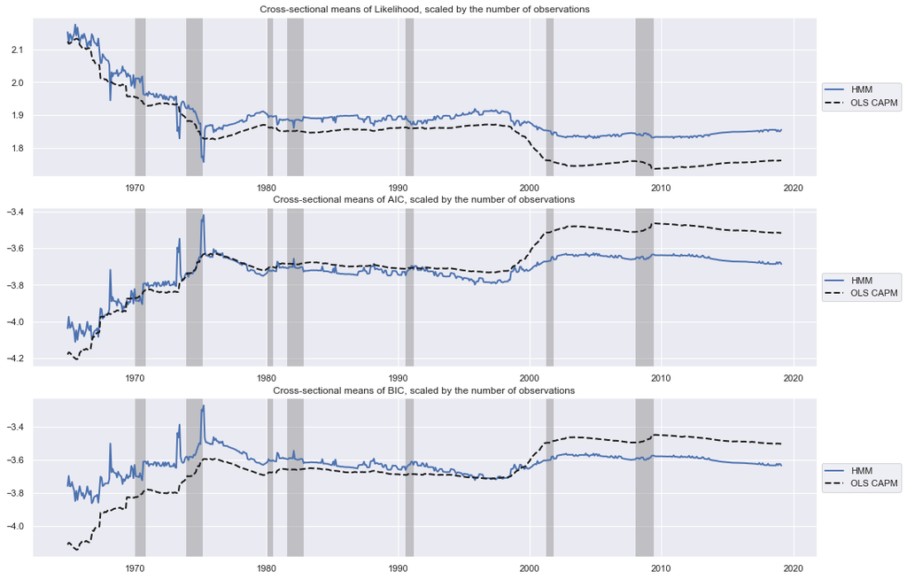

To take into account the suitability of the models the following analysis is **focused on the cases where the respective HMM model achieves a better fit than the one-state CAPM based on the Akaike criterion**.

#### Parameter Estimates

Next, we can again ask how different the two regimes really are, now on average over the many estimated models. For that purpose, the table below contains the spreads between the parameter estimates under both regimes. In addition, a test the statistical significance of the difference for each parameter pair is given by a two-sample t-statistic (as before), e.g. for $H_0: \beta^i_0=\beta^i_1$: $$t_{[\beta^i_0=\beta^i_1]} = \frac{\beta^i_0-\beta^i_1}{\sqrt{\big[s.e.(\beta^i_0)\big]^2+\big[s.e.(\beta^i_1)\big]^2 - 2 \, cov(\beta^i_0,\beta^i_1)}}$$ The table reports mean and standard deviation of parameters spreads, and the percentage of test statistics being significant at the 95% level.

[output not shown]

For a better economic interpretation, another way of looking at differences of coefficients under the two regimes is through a graphic. Below are the cumulative densities of the parameters spreads, e.g. $|\beta^i_0 - \beta^i_1|$, over all $i$ and $t$.

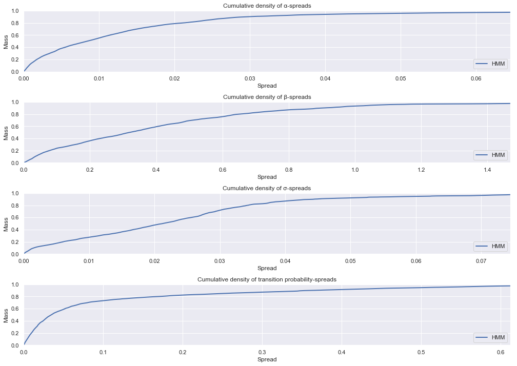

Analogue to the full-sample case, we report expected regime durations for the various industries. Values are now time-series means, and one standard deviation of these means are additionally marked as black lines in the chart. Note that there is substantial time-series variation, as confidence intervals are very large for some industries. Additionally, when comparing to the full-sample estimates, the ranking of industries has changed substantially.

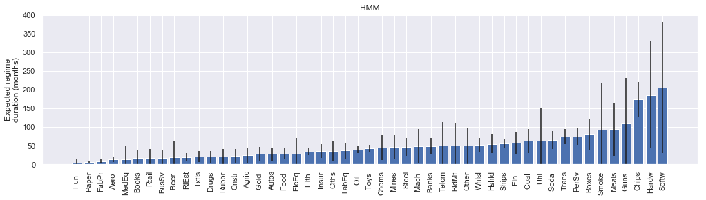

### Regime variation

To highlight periods of large regime changes, i.e. periods where the level of regime-innovations is high, let us look at the cross-sectional mean of first differences in regime probabilities. While the financial crisis of 2008 came with a large rise in regime innovations, this phenomenon is not consistently found for other recessions in the sample. Still, the arrival of regime innovations appears to be related to the business cycle to some extend (correlation = 0.2340, the conditional mean in recessions is 0.1383 vs 0.1023 in expansions for filtered probabilities).

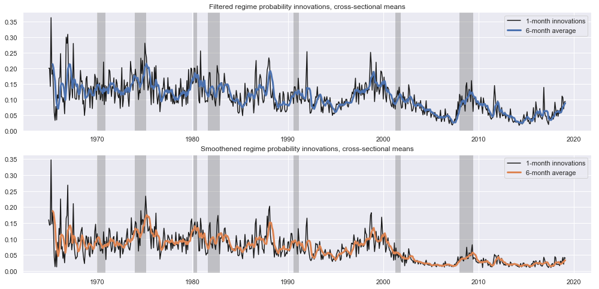

## The information content of the HMM CAPM

### Correlations

To further evaluate the usefulness of the Hidden Markov Models (HMM), we calculate correlations of parameter estimates of such models with their standard CAPM counterparts. In particular, we consider the following:

- **Mean weighted**: The Markov switching model parameter estimates weighted at the mean smoothed probabilities of the two regimes over the observation window.
- **Last period weighted**: The Markov switching model estimates weighted at the filtered regime-probabilities in the last month in the observation window.
- **Expected parameter**: The Markov switching model estimates weighted at the filtered regime-probabilities in the last month in the observation window, iterated forward by one month through the transition matrix.
- **Same period CAPM**: OLS estimates from CAPM regressions in the same observation window as in the HMM case.
- **Realised CAPM**: OLS estimates from CAPM regressions using 1 month of daily data.

Below there are six comparisons reported in the table (correlations):

- **Mean HMM vs. CAPM**: The first sanity check for the HMM models is to compare their estimates with the one-regime case of the standard CAPM. To have a sensible comparison, regime-parameters are weighted at the mean probabilites over the respective sample. Estimates obtained in such a way are very stongly correlated to their CAPM equivalents.
- **Last period weighted HMM at t vs. Realised at t**: Next, we ask if the most recent monthly estimates for each model are correlated with actually realised values. For that purpose, we correlate probability-weighted estimates at the end of each sample with realised CAPM estimates from daily data within the respective month. Correlations in this comparison indicate that HMM models do reasonably well in describing parameters realised within a given month. As a benchmark, the OLS CAPM is additionally correlated to the realised regressions, providing weaker correlations. Note that this is a contemperaneous relation, not a predictive one.
- **Expected HMM parameter at t-1 vs. Realised at t**: We then examine the predictive ability of HMM models with regards to realised volatility in the subsequent month. Instead of using static regime-probabilities, we can iterate one period forward by using the transition matrix. Such predicted regime probabilities are obtained purely from historical data and can therefore serve as a 1-month forecast. Compared to the previous contemperaneous relation, correlations are much smaller. Especially puzzling is the non-existence of predictive power with regards to idiosyncratic volatility, especially when benchmarked against OLS estimates.
- **OLS CAPM at t vs. Realised at t**: The expanding window estimates are modereately correlated to the realised values in the final month.
- **OLS CAPM at t vs. Realised at t+1**: When looking at the predictive relation, not much changes as compared to the contemperaneous relation as expanding window OLS estimates are almost perfectly autocorreled.
- **Realised at t vs. Realised at t+1**: To complete the list of benchmarks, the autocorrelations of realised regression estimates are also reported.

The table contains Pearson correlation coefficients calculated over all time periods and assets given the above described sample restrictons.

|  |  | OLS CAPM α | OLS CAPM β | OLS CAPM σ² | Realised (t) α | Realised (t) β | Realised (t) σ² |
| --- | --- | --- | --- | --- | --- | --- | --- |
| HMM | Mean weighted | 0.9680 | 0.9846 | 0.9928 |  |  |  |
|  | Last period weighted (t) |  |  |  | 0.1312 | 0.3752 | 0.5564 |
|  | Expected parameter (t-1) |  |  |  | 0.0124 | 0.2433 | -0.0049 |
| OLS CAPM | Contemperaneous |  |  |  | 0.0565 | 0.3381 | 0.4142 |
|  | Predictive |  |  |  | 0.0532 | 0.3356 | 0.4122 |
| Realised (t-1) | Autocorrelation |  |  |  | 0.0444 | 0.5395 | 0.6603 |

### Predictive panel regressions

**WORK IN PROGRESS: This part is not finished**

#### Predicting realised parameters

Next, we let the different models compete against each other with regards to their predictive power. For that purpose, predictive panel regressions of the following form are estimated: $$\theta^{real,i}_{t} = (\gamma_0) + \gamma_1 \theta^{OLS,i}_{t-1} + \gamma_2 \theta^{real,i}_{t-1} + \gamma_3 \theta^{HMM expected, i}_{t-1} + (\tau_t) + (\eta_i) + \epsilon^i_{t}$$ $\theta$ are the estimated $\alpha$,$\beta$ or $\sigma^2$ from the respective model, and $\tau_t$ and $\eta_i$ are time- and industry fixed effects.

Reported in the table below are the estimates and t-statistics (Driscoll-Kraay) from such regressions. Additionally, the R² of such regressions is reported both for the regressors only, and for the regressors together with the fixed effects.

However the estimation through static panel data techniques (standard fixed effects estimation) is inconsistent and right hand side variables should be instrumented appropriately (e.g. Arellano-Bond GMM estimator). Therefore the values in this table are invalid at the current stage.

|  | parameter | alpha 1 | alpha 2 | alpha 3 | alpha 4 | beta 1 | beta 2 | beta 3 | beta 4 | sigma2 1 | sigma2 2 | sigma2 3 | sigma2 4 |
| --- | --- | --- | --- | --- | --- | --- | --- | --- | --- | --- | --- | --- | --- |
| constant | est. | -0.0000 |  |  |  | 0.1052 |  |  |  | 0.0000 |  |  |  |
|  | t-stat | -0.5073 |  |  |  | 3.9815 |  |  |  | 1.4835 |  |  |  |
| OLS | est. | -0.0409 | -0.0350 | -0.0427 | -0.0329 | 0.0529 | 0.0979 | 0.1131 | 0.3143 | -0.0072 | -0.0054 | -0.0046 | 0.0027 |
|  | t-stat | -3.8427 | -3.2325 | -2.2146 | -1.7928 | 1.3882 | 2.5366 | 1.8119 | 4.4888 | -3.2347 | -2.5127 | -0.9156 | 0.5483 |
| Realised CAPM | est. | 0.0126 | 0.0046 | 0.0085 | 0.0005 | 0.5018 | 0.4768 | 0.4565 | 0.4239 | 0.4721 | 0.4423 | 0.4516 | 0.4101 |
|  | t-stat | 0.9978 | 0.3560 | 0.6908 | 0.0422 | 22.6709 | 23.1417 | 19.6632 | 20.1513 | 13.4785 | 12.1591 | 12.3971 | 10.5611 |
| HMM expected | est. | 0.0825 | 0.0767 | 0.0909 | 0.0847 | 0.2879 | 0.2786 | 0.2615 | 0.2446 | 0.0306 | 0.0297 | 0.0284 | 0.0248 |
|  | t-stat | 11.1032 | 10.1787 | 12.8737 | 12.0813 | 8.2690 | 8.2322 | 7.4300 | 7.2790 | 9.1930 | 8.9357 | 7.8226 | 7.0400 |
| fixed effects | time |  | True |  | True |  | True |  | True |  | True |  | True |
|  | industry |  |  | True | True |  |  | True | True |  |  | True | True |
| stats | R² (model) | 0.0301 | 0.0262 | 0.0324 | 0.0283 | 0.3629 | 0.3521 | 0.2499 | 0.2279 | 0.5038 | 0.4895 | 0.3925 | 0.3525 |
|  | R² (inclusive) | 0.0301 | 0.1057 | 0.0345 | 0.1097 | 0.3629 | 0.4089 | 0.3822 | 0.4302 | 0.5038 | 0.5684 | 0.5106 | 0.5774 |
|  | N | 24544 | 24544 | 24544 | 24544 | 24544 | 24544 | 24544 | 24544 | 24544 | 24544 | 24544 | 24544 |

#### Predicting returns

##### Same regression

Less problematic are regressions where the left-hand side variable is return: $$return^{real,i}_{t} = (\gamma_0) + \gamma_1 \theta^{OLS,i}_{t-1} + \gamma_2 \theta^{real,i}_{t-1} + \gamma_3 \theta^{HMM expected, i}_{t-1} + (\tau_t) + (\eta_i) + \epsilon^i_{t}$$

|  | parameter | alpha 1 | alpha 2 | alpha 3 | alpha 4 | beta 1 | beta 2 | beta 3 | beta 4 | sigma2 1 | sigma2 2 | sigma2 3 | sigma2 4 |
| --- | --- | --- | --- | --- | --- | --- | --- | --- | --- | --- | --- | --- | --- |
| constant | est. | 0.0063 |  |  |  | 0.0073 |  |  |  | 0.0065 |  |  |  |
|  | t-stat | 3.0098 |  |  |  | 1.9128 |  |  |  | 3.3879 |  |  |  |
| OLS | est. | -0.4380 | -0.3884 | -1.3414 | -1.3996 | -0.0035 | 0.0006 | -0.0178 | -0.0128 | 0.0001 | -0.0735 | -0.6246 | -0.9544 |
|  | t-stat | -1.4290 | -1.6321 | -2.0402 | -3.1008 | -0.6873 | 0.1452 | -1.1544 | -1.4521 | 0.0002 | -0.1663 | -0.5146 | -1.0996 |
| Realised CAPM | est. | -0.0606 | -0.2043 | -0.0792 | -0.2180 | 0.0022 | 0.0007 | 0.0025 | 0.0008 | -3.0855 | -2.5146 | -2.8217 | -2.0763 |
|  | t-stat | -0.1518 | -0.6314 | -0.2015 | -0.6869 | 1.1149 | 0.4179 | 1.2928 | 0.4961 | -0.3691 | -0.4275 | -0.3196 | -0.3335 |
| HMM expected | est. | 0.2834 | 0.2362 | 0.3901 | 0.3351 | 0.0008 | -0.0017 | 0.0017 | -0.0013 | 0.0645 | 0.1160 | 0.2418 | 0.3939 |
|  | t-stat | 1.7022 | 1.7853 | 2.2224 | 2.5683 | 0.1864 | -0.4265 | 0.3864 | -0.3158 | 0.1072 | 0.2273 | 0.3250 | 0.7023 |
| fixed effects | time |  | True |  | True |  | True |  | True |  | True |  | True |
|  | industry |  |  | True | True |  |  | True | True |  |  | True | True |
| stats | R² (model) | 0.0004 | 0.0006 | 0.0010 | 0.0019 | 0.0002 | 0.0001 | 0.0006 | 0.0005 | 0.0001 | 0.0001 | 0.0001 | 0.0003 |
|  | R² (inclusive) | 0.0004 | 0.5265 | 0.0019 | 0.5278 | 0.0002 | 0.5262 | 0.0016 | 0.5271 | 0.0001 | 0.5262 | 0.0011 | 0.5270 |
|  | N | 24544 | 24544 | 24544 | 24544 | 24544 | 24544 | 24544 | 24544 | 24544 | 24544 | 24544 | 24544 |

##### Separate regressions

A remaining concern in the previous specification is the multicollinearity of the right-hand side variables. Therefore, another comparison of the models is to run tests of their predictive power in separate regressions and compare significance and goodness of fit: $$return^{real,i}_{t} = (\gamma_0) + \gamma_1 \alpha^{model,i}_{t-1} + \gamma_2 \beta^{model,i}_{t-1} + \gamma_3 (\sigma^2)^{model, i}_{t-1} + (\tau_t) + (\eta_i) + \epsilon^i_{t}$$

|  | model | OLS 1 | OLS 2 | OLS 3 | OLS 4 | Realised CAPM 1 | Realised CAPM 2 | Realised CAPM 3 | Realised CAPM 4 | HMM 1 | HMM 2 | HMM 3 | HMM 4 |
| --- | --- | --- | --- | --- | --- | --- | --- | --- | --- | --- | --- | --- | --- |
| constant | est. | 0.0100 |  |  |  | 0.0049 |  |  |  | 0.0060 |  |  |  |
|  | t-stat | 1.9887 |  |  |  | 2.3562 |  |  |  | 1.7860 |  |  |  |
| alpha | est. | -0.3151 | -0.3052 | -1.3924 | -1.7549 | 0.0461 | -0.1410 | 0.0238 | -0.1717 | 0.1724 | 0.1227 | 0.1629 | 0.0917 |
|  | t-stat | -0.9089 | -1.5042 | -1.9998 | -3.9202 | 0.1179 | -0.4511 | 0.0613 | -0.5552 | 1.1954 | 1.0570 | 1.0194 | 0.7760 |
| beta | est. | -0.0029 | -0.0019 | -0.0152 | -0.0139 | 0.0018 | 0.0004 | 0.0022 | 0.0003 | 0.0004 | -0.0003 | -0.0016 | -0.0034 |
|  | t-stat | -0.6351 | -0.6451 | -0.9156 | -1.9492 | 1.0097 | 0.2416 | 1.2124 | 0.1990 | 0.1056 | -0.0884 | -0.2700 | -0.8557 |
| sigma2 | est. | -0.0568 | -0.1093 | -1.0577 | -1.4953 | -2.7280 | -2.0954 | -3.4299 | -2.7898 | -0.1236 | -0.0788 | -0.1395 | -0.0650 |
|  | t-stat | -0.1995 | -0.3863 | -1.2836 | -2.2407 | -0.3774 | -0.3783 | -0.4021 | -0.4383 | -0.3379 | -0.2332 | -0.2531 | -0.1464 |
| fixed effects | time |  | True |  | True |  | True |  | True |  | True |  | True |
|  | industry |  |  | True | True |  |  | True | True |  |  | True | True |
| stats | R² (model) | 0.0001 | 0.0002 | 0.0012 | 0.0029 | 0.0002 | 0.0001 | 0.0003 | 0.0002 | 0.0002 | 0.0002 | 0.0002 | 0.0003 |
|  | R² (inclusive) | 0.0001 | 0.5263 | 0.0022 | 0.5283 | 0.0002 | 0.5263 | 0.0012 | 0.5270 | 0.0002 | 0.5263 | 0.0011 | 0.5270 |
|  | N | 24544 | 24544 | 24544 | 24544 | 24544 | 24544 | 24544 | 24544 | 24544 | 24544 | 24544 | 24544 |